# Projekt z przedmiotu Automatyczna analiza obrazu

Budowa optymalnego modelu klasyfikującego zdjęcia RTG

Author

Weronika Nadworska

## Cel projektu

Uczenie maszynowe ma szerokie zastosowanie w analizowaniu obrazów. Modele sieci neuronowych umożliwiają rozwiązanie wielu zadań różnych typów, które mają swoje zastosowanie w różnych dziedzinach. Przykładowe ich zastosowania to medycyna, gdzie modele te są wykorzystywane do wykrywania np. zmian nowotworowych, bądź innych zmian w różnego rodzaju prześwietleniach. Uczenie maszynowe wykorzystywane jest także przez policję oraz inne służby, na przykład podczas rozpoznawania przestępców na materiałach z kamer miejskich oraz tablic rejestracyjnych pojazdów. Analiza obrazu wykorzystywana jest również przy produkcji pojazdów autonomicznych, które posiadają kamery, które wychwytują otoczenie auta, aby umożliwić mu na przykład ominięcie innego auta stojącego na ulicy, bądź ustąpienie pierwszeństwa pieszemu.

Celem tego projektu jest zbudowanie optymalnej sieci neuronowej, która będzie klasyfikowała obrazy przedstawiające zdjęcia RTG klatek piersiowych osób aby wykryć, czy dana osoba choruje na zapanienie płuc, czy nie. Zatem jest to zadanie klasyfikacji dwustanowej.

## Opis zbioru badawczego

Dane pochodzą ze strony [huggingface.co](https://huggingface.co/datasets/keremberke/chest-xray-classification). Zawierają obrazy przedstawiające prześwietlenia RTG klatek piersiowych ludzi.

Zbiór uczący zwiera 4077 obrazów (1104 *Normal*, 2973 *Pneumonia*), zbiór walidacyjny zawiera 1165 obrazów (304 *Normal*, 861 *Pneumonia*), zbiór testowy zawiera 582 obrazy (171 *Normal*, 411 *Pneumonia*), gdzie *Normal* oraz *Pneumonia* oznaczają odpowiednio “brak zapalenia płuc” oraz “zapalenie płuc”.

Poniżej przedstawiono kilka przykładowych obrazów tego zbioru.

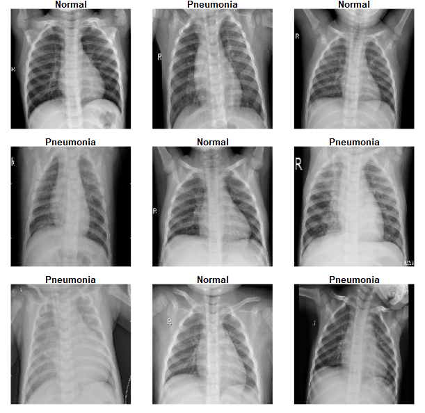

Każdy obraz ma wymiary 640 px $\times$ 640 px. Aby przyspieszyć procedurę uczenia modeli, rozmiar ten przy wczytywaniu danych został zmniejszony do wymiarów 150 px $\times$ 150 px.

## Wczytanie danych

Na początku każdy ze zbiorów z obrazami - uczący, walidacyjny oraz testowy - zostały wczytane. Następnie zdekodowane zostały zawartości JPEG na siatki pikseli RGB oraz przekształcono je na tensory zmiennoprzecinkowe. Na koniec przeskalowano wartości pikseli do przedziału $[0, 1]$. Wszystkie te działania można przeprowadzić za pomocą funkcji biblioteki `keras`, która zawiera wiele narzędzi pomocniczych do przetwarzania obrazów. Zawiera m. in. funkcję `image_data_generator()`, która służy do generowania partii wstępnie przetworzonych tensorów z plików graficznych na dysku.

Struktura takiego wstępnie przetworzonego generatora obrazów treningowych prezentuje się następująco:

```
List of 2
 $ : num [1:20, 1:150, 1:150, 1:3] 0.8118 0.1922 0 0.0431 0.1647 ...
 $ : num [1:20(1d)] 1 1 1 1 0 1 1 1 0 0 ...
```

Zawiera on partie obrazów RGB o wymiarach 150 $\times$ 150 oraz binarne etykiety. W każdej takiej partii znajduje się 20 próbek (rozmiar każdej partii).

## Budowa modeli

W tym projekcie zaprezentowanych zostanie kilka modeli, aby przedstawić różne architektury oraz możliwości sieci neuronowych.

#### Model rozbudowany

Na początku, aby dowiedzieć się, jak duży model będzie potrzebny do tego zadania klasyfikacyjnego, trzeba opracować taki, który jest nadmiernie dopasowany.

W kroku kompilacji użyjemy optymalizatora `RMSprop` ze współczynnikiem szybkości uczenia równym 0,001. Ze względu na klasyfikację dwustanową, a zatem i funkcję sigmoidalną, jako funkcję straty zostanie użyta binarna entropia krzyżowa. Te dwa ustawienia będą zastosowane do wszytskich zaprezentowanych tu modeli.

Porównywać modele będziemy za pomocą metryki *accuracy*.

Poniżej prezentuje się architektura całej sieci.

```
Model: "sequential"
_____________________________________________________________________
Layer (type)                   Output Shape               Param #
=====================================================================
conv2d_4 (Conv2D)              (None, 148, 148, 32)       896
_____________________________________________________________________
batch_normalization_4 (BatchNo (None, 148, 148, 32)       128
_____________________________________________________________________
max_pooling2d_4 (MaxPooling2D) (None, 74, 74, 32)         0
_____________________________________________________________________
conv2d_3 (Conv2D)              (None, 72, 72, 64)         18496
_____________________________________________________________________
dropout_3 (Dropout)            (None, 72, 72, 64)         0
_____________________________________________________________________
batch_normalization_3 (BatchNo (None, 72, 72, 64)         256
_____________________________________________________________________
max_pooling2d_3 (MaxPooling2D) (None, 36, 36, 64)         0
_____________________________________________________________________
conv2d_2 (Conv2D)              (None, 34, 34, 64)         36928
_____________________________________________________________________
batch_normalization_2 (BatchNo (None, 34, 34, 64)         256
_____________________________________________________________________
max_pooling2d_2 (MaxPooling2D) (None, 17, 17, 64)         0
_____________________________________________________________________
conv2d_1 (Conv2D)              (None, 15, 15, 128)        73856
_____________________________________________________________________
dropout_2 (Dropout)            (None, 15, 15, 128)        0
_____________________________________________________________________
batch_normalization_1 (BatchNo (None, 15, 15, 128)        512
_____________________________________________________________________
max_pooling2d_1 (MaxPooling2D) (None, 7, 7, 128)          0
_____________________________________________________________________
conv2d (Conv2D)                (None, 5, 5, 256)          295168
_____________________________________________________________________
dropout_1 (Dropout)            (None, 5, 5, 256)          0
_____________________________________________________________________
batch_normalization (BatchNorm (None, 5, 5, 256)          1024
_____________________________________________________________________
max_pooling2d (MaxPooling2D)   (None, 2, 2, 256)          0
_____________________________________________________________________
flatten (Flatten)              (None, 1024)               0
_____________________________________________________________________
dense_1 (Dense)                (None, 128)                131200
_____________________________________________________________________
dropout (Dropout)              (None, 128)                0
_____________________________________________________________________
dense (Dense)                  (None, 1)                  129
=====================================================================
Total params: 558,849
Trainable params: 557,761
Non-trainable params: 1,088
_____________________________________________________________________
```

Poniżej zaprezentowano proces uczenia się tego modelu na 30 epokach.

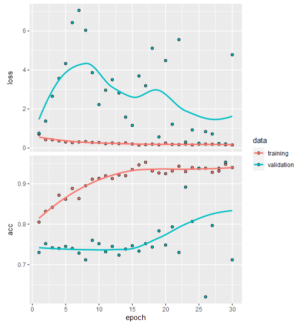

Jak widać, występuje przeuczenie modelu - wysokie dpasowanie jest na zbiorze uczącym (*accuracy* osiąga wartość ponad 0,9), a niskie na zbiorze walidacyjnym (przez większość epok to wartość około 0,7, a pod koniec 0,8).

Po dokonaniu ewaluacji tego modelu na zbiorze testowym, otrzymano sieć o dokładności 71%.

Mając model nadmiernie dopasowany, trzeba przeprowadzić regularyzacje oraz dostroić model, aby zbliżyć się jak najbardziej do idealnego modelu, który nie jest ani niedopasowany, ani nadmiernie dopasowany. Można to zrobić m. in. poprzez zmianę architektury sieci - dodanie lub usunięcie warstw czy liczby neuronów, z których są one zbudowane oraz dodanie warstw `layer_dropout`.

#### Propozycje innych modeli

Poniżej przedstawiono kilka modeli, które zostały przekształcone z modelu rozbudowanego do różnych architektur.

- Model złożony z 4 stosów naprzemiennych warstw: `layer_conv_2d` z aktywacją `relu`, `layer_dropout(0.5)` oraz `layer_max_pooling_2d` . Następnie jedna sieć gęsta z 512 neuronami oraz druga z 1 neuronem i aktywacją `sigmoid`.

  Podobnie jak w poprzednim modelu, w kroku kompilacji użyjemy optymalizatora `RMSprop` ze współczynnikiem szybkości uczenia równym 0,001 oraz jako funkcję straty binarną entropię krzyżową.

  ```
  Model: "sequential_1"
  ________________________________________________________________________________
  Layer (type)                        Output Shape                    Param #
  ================================================================================
  conv2d_8 (Conv2D)                   (None, 148, 148, 32)            896
  ________________________________________________________________________________
  dropout_7 (Dropout)                 (None, 148, 148, 32)            0
  ________________________________________________________________________________
  max_pooling2d_8 (MaxPooling2D)      (None, 74, 74, 32)              0
  ________________________________________________________________________________
  conv2d_7 (Conv2D)                   (None, 72, 72, 64)              18496
  ________________________________________________________________________________
  dropout_6 (Dropout)                 (None, 72, 72, 64)              0
  ________________________________________________________________________________
  max_pooling2d_7 (MaxPooling2D)      (None, 36, 36, 64)              0
  ________________________________________________________________________________
  conv2d_6 (Conv2D)                   (None, 34, 34, 128)             73856
  ________________________________________________________________________________
  dropout_5 (Dropout)                 (None, 34, 34, 128)             0
  ________________________________________________________________________________
  max_pooling2d_6 (MaxPooling2D)      (None, 17, 17, 128)             0
  ________________________________________________________________________________
  conv2d_5 (Conv2D)                   (None, 15, 15, 256)             295168
  ________________________________________________________________________________
  dropout_4 (Dropout)                 (None, 15, 15, 256)             0
  ________________________________________________________________________________
  max_pooling2d_5 (MaxPooling2D)      (None, 7, 7, 256)               0
  ________________________________________________________________________________
  flatten_1 (Flatten)                 (None, 12544)                   0
  ________________________________________________________________________________
  dense_3 (Dense)                     (None, 512)                     6423040
  ________________________________________________________________________________
  dense_2 (Dense)                     (None, 1)                       513
  ================================================================================
  Total params: 6,811,969
  Trainable params: 6,811,969
  Non-trainable params: 0
  ________________________________________________________________________________
  ```

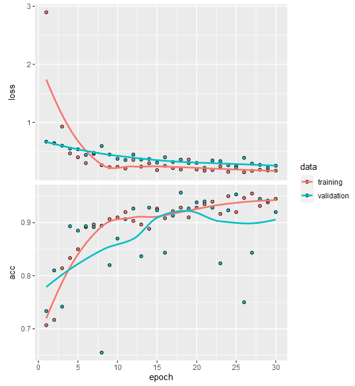

Jak widać, przeuczenie modelu spadło. Funkcja straty w miarę procesu uczenia również zmniejsza swoje wartości.

Po dopasowaniu modelu do danych testowych, wartość *accuracy* dla tego modelu wynosi 88%.

- Model złożony z 4 stosów naprzemiennych warstw: `layer_conv_2d` z aktywacją `relu` oraz `layer_max_pooling_2d`. Po nich następuje warstwa `layer_flatten`, następnie jedna warstwa gęsta z 512 neuronami i aktywacją `relu`, a sieć zakończy warstwa `layer_dense` o rozmiarze 1 i aktywacją `sigmoid`.

  Optymalizator oraz funkcja straty pozostają bez zmian.

```
Model: "sequential_2"
________________________________________________________________________________
Layer (type)                        Output Shape                    Param #
================================================================================
conv2d_12 (Conv2D)                  (None, 148, 148, 32)            896
________________________________________________________________________________
max_pooling2d_12 (MaxPooling2D)     (None, 74, 74, 32)              0
________________________________________________________________________________
conv2d_11 (Conv2D)                  (None, 72, 72, 64)              18496
________________________________________________________________________________
max_pooling2d_11 (MaxPooling2D)     (None, 36, 36, 64)              0
________________________________________________________________________________
conv2d_10 (Conv2D)                  (None, 34, 34, 128)             73856
________________________________________________________________________________
max_pooling2d_10 (MaxPooling2D)     (None, 17, 17, 128)             0
________________________________________________________________________________
conv2d_9 (Conv2D)                   (None, 15, 15, 256)             295168
________________________________________________________________________________
max_pooling2d_9 (MaxPooling2D)      (None, 7, 7, 256)               0
________________________________________________________________________________
flatten_2 (Flatten)                 (None, 12544)                   0
________________________________________________________________________________
dense_5 (Dense)                     (None, 512)                     6423040
________________________________________________________________________________
dense_4 (Dense)                     (None, 1)                       513
================================================================================
Total params: 6,811,969
Trainable params: 6,811,969
Non-trainable params: 0
________________________________________________________________________________
```

Poniżej przedstawiono proces uczenia się tego modelu na 30 epokach.

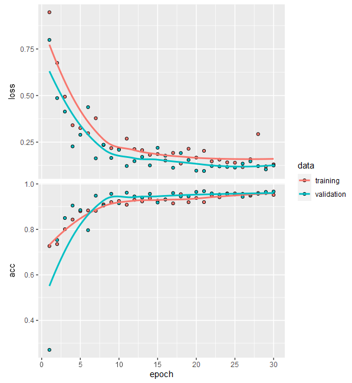

Jak widać, nie występuje tu zjawisko przeuczenia modelu, mamy bardzo dobre dopasowanie na zbiorze uczącym oraz walidacyjnym.

Po dokonaniu ewaluacji tego modelu na danych testowych otrzymano *accuracy* na poziomie 94%.

- Model złożony z 5 stosów naprzemiennych warstw: `layer_conv_2d` z aktywacją `relu` oraz `layer_max_pooling_2d`. Po nich następuje warstwa `layer_flatten`, następnie jedna warstwa gęsta o rozmiarze 512 i aktywacją `relu` oraz warstwa `layer_dense` o rozmiarze 1 i aktywacją `sigmoid`. Poszczególne warstwy `layer_conv_2d` mają nieco większą liczbę filtrów w porównaniu do wcześniejszego modelu.

```
Model: "sequential_3"
________________________________________________________________________________
Layer (type)                        Output Shape                    Param #
================================================================================
conv2d_17 (Conv2D)                  (None, 148, 148, 64)            1792
________________________________________________________________________________
max_pooling2d_17 (MaxPooling2D)     (None, 74, 74, 64)              0
________________________________________________________________________________
conv2d_16 (Conv2D)                  (None, 72, 72, 128)             73856
________________________________________________________________________________
max_pooling2d_16 (MaxPooling2D)     (None, 36, 36, 128)             0
________________________________________________________________________________
conv2d_15 (Conv2D)                  (None, 34, 34, 128)             147584
________________________________________________________________________________
max_pooling2d_15 (MaxPooling2D)     (None, 17, 17, 128)             0
________________________________________________________________________________
conv2d_14 (Conv2D)                  (None, 15, 15, 256)             295168
________________________________________________________________________________
max_pooling2d_14 (MaxPooling2D)     (None, 7, 7, 256)               0
________________________________________________________________________________
conv2d_13 (Conv2D)                  (None, 5, 5, 256)               590080
________________________________________________________________________________
max_pooling2d_13 (MaxPooling2D)     (None, 2, 2, 256)               0
________________________________________________________________________________
flatten_3 (Flatten)                 (None, 1024)                    0
________________________________________________________________________________
dense_7 (Dense)                     (None, 512)                     524800
________________________________________________________________________________
dense_6 (Dense)                     (None, 1)                       513
================================================================================
Total params: 1,633,793
Trainable params: 1,633,793
Non-trainable params: 0
________________________________________________________________________________
```

Preces uczenia się tego modelu na 30 epokach wygląda następująco:

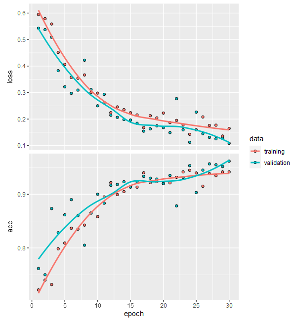

Mimo, że model jest nieco bardziej rozbudowany niż poprzedni, nadal osiąga bardzo dobre wyniki w miarach dopasowania.

Dopasowanie tego modelu do danych testowych osiąga 94%.

- Model złożony z 4 stosów naprzemiennych warstw `layer_conv_2d` oraz `layer_max_pooling_2d`, a następnie warstwa `layer_flatten` oraz warstwa `layer_dense` o rozmiarze 512 i ta sama warstwa o rozmiarze 1 i aktywacją sigmoidalną. Ten model ma nieco inną liczbę filtrów w poszczególnych warstwach niż drugi zaprezentowany w tej sekcji.

```
Model: "sequential_4"
________________________________________________________________________________
Layer (type)                        Output Shape                    Param #
================================================================================
conv2d_21 (Conv2D)                  (None, 148, 148, 16)            448
________________________________________________________________________________
max_pooling2d_21 (MaxPooling2D)     (None, 74, 74, 16)              0
________________________________________________________________________________
conv2d_20 (Conv2D)                  (None, 72, 72, 64)              9280
________________________________________________________________________________
max_pooling2d_20 (MaxPooling2D)     (None, 36, 36, 64)              0
________________________________________________________________________________
conv2d_19 (Conv2D)                  (None, 34, 34, 128)             73856
________________________________________________________________________________
max_pooling2d_19 (MaxPooling2D)     (None, 17, 17, 128)             0
________________________________________________________________________________
conv2d_18 (Conv2D)                  (None, 15, 15, 256)             295168
________________________________________________________________________________
max_pooling2d_18 (MaxPooling2D)     (None, 7, 7, 256)               0
________________________________________________________________________________
flatten_4 (Flatten)                 (None, 12544)                   0
________________________________________________________________________________
dense_9 (Dense)                     (None, 512)                     6423040
________________________________________________________________________________
dense_8 (Dense)                     (None, 1)                       513
================================================================================
Total params: 6,802,305
Trainable params: 6,802,305
Non-trainable params: 0
________________________________________________________________________________
```

Preces uczenia tego modelu wygląda następująco:

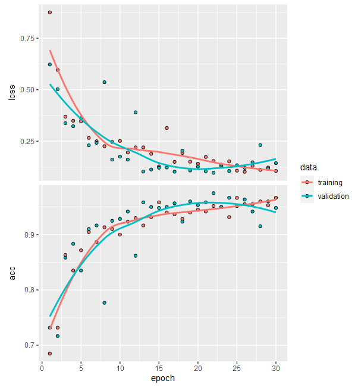

Nie występuje tu zjawisko przeuczenia. Miara *accuracy* osiąga poziom ponad 0,9.

Dopasowanie tego modelu do danych testowych wynosi 95%.

#### Model z inną architekturą

Poniższy model został zbudowany z nieco inną architekturą. Składa się on z warstwy *input*, dwóch bloków konwolucyjnych oraz warstwy *output*.

Pierwszy blok konwolucyjny składa się z trzech stosów naprzemiennych warstw `layer_conv_2d` z parametrem `padding="same"` oraz `layer_activation_leaky_relu(0.1)`, pomiędzy nimi jest też warstwa `layer_dropout(0.25)`.

Drugi blok konwolucyjny to warstwa `layer_flatten` oraz warstwa `layer_dense` o rozmiarze 512 z aktywacją `relu`.

Na wyjściu tego modelu jest sieć gęsta o rozmiarze 1 z aktywacją `sigmoid` ze względu na klasyfikację dwustanową.

```
Model: "model"
________________________________________________________________________________
Layer (type)                        Output Shape                    Param #
================================================================================
input_1 (InputLayer)                [(None, 150, 150, 3)]           0
________________________________________________________________________________
conv2d_24 (Conv2D)                  (None, 150, 150, 16)            448
________________________________________________________________________________
leaky_re_lu_2 (LeakyReLU)           (None, 150, 150, 16)            0
________________________________________________________________________________
conv2d_23 (Conv2D)                  (None, 150, 150, 32)            4640
________________________________________________________________________________
leaky_re_lu_1 (LeakyReLU)           (None, 150, 150, 32)            0
________________________________________________________________________________
max_pooling2d_22 (MaxPooling2D)     (None, 75, 75, 32)              0
________________________________________________________________________________
dropout_9 (Dropout)                 (None, 75, 75, 32)              0
________________________________________________________________________________
conv2d_22 (Conv2D)                  (None, 75, 75, 64)              18496
________________________________________________________________________________
leaky_re_lu (LeakyReLU)             (None, 75, 75, 64)              0
________________________________________________________________________________
dropout_8 (Dropout)                 (None, 75, 75, 64)              0
________________________________________________________________________________
flatten_5 (Flatten)                 (None, 360000)                  0
________________________________________________________________________________
dense_10 (Dense)                    (None, 512)                     184320512
________________________________________________________________________________
dense_11 (Dense)                    (None, 1)                       513
================================================================================
Total params: 184,344,609
Trainable params: 184,344,609
Non-trainable params: 0
________________________________________________________________________________
```

Proces uczenia tego modelu na 30 epokach wygląda następująco:

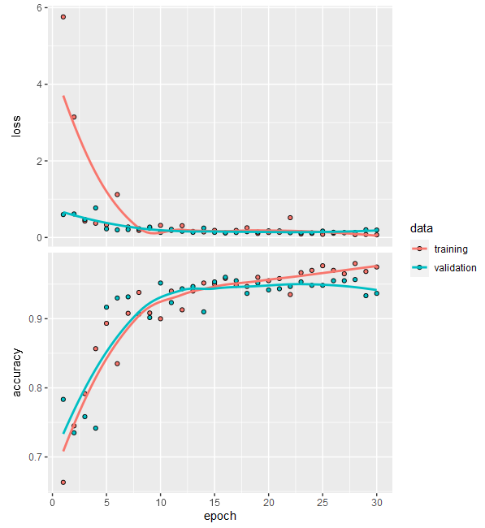

Tutaj widzimy, że przeuczenie modelu nie występuje. Jedynie od około 25. epoki dopasowanie modelu na danych walidacyjnych nieco spada. Model osiąga bardzo dobre wyniki. Wartość *accuracy* zarówno na zbiorze uczącym, jak i walidacyjnym osiąga ponad dziewięćdziesięcioprocentowe wartości.

Dokonano także ewaluacji tego modelu na danych testowych i dopasowanie osiąga tam 93% ze względu na metrykę *accuracy*.

#### Model z użyciem VGG16

Użyta zostanie także wstępnie wytrenowana sieć VGG16 na zbiorze *ImageNet,* która jest w stanie sklasyfikować 1000 obrazów należących do 1000 różnych kategorii.

Składa się ona z trzynastu warstw splotowych, pięciu warstw *max pooling* i trzech warstw gęstych.

Wykorzystane zostaną reprezentacje wyuczone przez tę sieć do wyodrębnienia interesujących cech z nowych próbek. Cechy te będą następnie przepuszczane przez nowy klasyfikator, który jest trenowany od podstaw.

Wagi wytrenowanej sieci konwolucyjnej zostaną zamrożone, a nowy klasyfikator będzie się składał z trzech warstw `layer_dense`, odpowiednio o rozmriarach 256 i 512 z aktywacjami `relu` oraz o rozmiarze 1 z aktywacją `sigmoid`.

```
Model: "vgg16"
________________________________________________________________________________
Layer (type)                        Output Shape                    Param #
================================================================================
input_2 (InputLayer)                [(None, 150, 150, 3)]           0
________________________________________________________________________________
block1_conv1 (Conv2D)               (None, 150, 150, 64)            1792
________________________________________________________________________________
block1_conv2 (Conv2D)               (None, 150, 150, 64)            36928
________________________________________________________________________________
block1_pool (MaxPooling2D)          (None, 75, 75, 64)              0
________________________________________________________________________________
block2_conv1 (Conv2D)               (None, 75, 75, 128)             73856
________________________________________________________________________________
block2_conv2 (Conv2D)               (None, 75, 75, 128)             147584
________________________________________________________________________________
block2_pool (MaxPooling2D)          (None, 37, 37, 128)             0
________________________________________________________________________________
block3_conv1 (Conv2D)               (None, 37, 37, 256)             295168
________________________________________________________________________________
block3_conv2 (Conv2D)               (None, 37, 37, 256)             590080
________________________________________________________________________________
block3_conv3 (Conv2D)               (None, 37, 37, 256)             590080
________________________________________________________________________________
block3_pool (MaxPooling2D)          (None, 18, 18, 256)             0
________________________________________________________________________________
block4_conv1 (Conv2D)               (None, 18, 18, 512)             1180160
________________________________________________________________________________
block4_conv2 (Conv2D)               (None, 18, 18, 512)             2359808
________________________________________________________________________________
block4_conv3 (Conv2D)               (None, 18, 18, 512)             2359808
________________________________________________________________________________
block4_pool (MaxPooling2D)          (None, 9, 9, 512)               0
________________________________________________________________________________
block5_conv1 (Conv2D)               (None, 9, 9, 512)               2359808
________________________________________________________________________________
block5_conv2 (Conv2D)               (None, 9, 9, 512)               2359808
________________________________________________________________________________
block5_conv3 (Conv2D)               (None, 9, 9, 512)               2359808
________________________________________________________________________________
block5_pool (MaxPooling2D)          (None, 4, 4, 512)               0
================================================================================
Total params: 14,714,688
Trainable params: 14,714,688
Non-trainable params: 0
________________________________________________________________________________
```

```
Model: "sequential_5"
_____________________________________________________________________
Layer (type)                   Output Shape               Param #
=====================================================================
vgg16 (Functional)             (None, 4, 4, 512)          14714688
_____________________________________________________________________
flatten_6 (Flatten)            (None, 8192)               0
_____________________________________________________________________
dense_14 (Dense)               (None, 256)                2097408
_____________________________________________________________________
dense_13 (Dense)               (None, 512)                131584
_____________________________________________________________________
dense_12 (Dense)               (None, 1)                  513
=====================================================================
Total params: 16,944,193
Trainable params: 2,229,505
Non-trainable params: 14,714,688
_____________________________________________________________________
```

Poniżej przedstawiono proces uczenia się tego modelu.

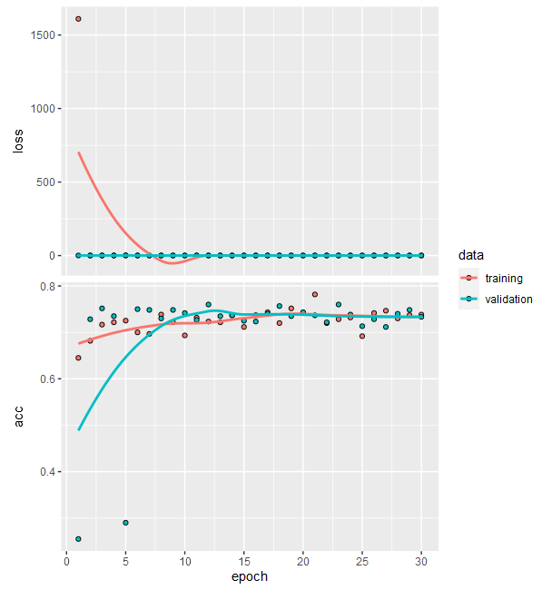

Ewaluacja modelu na danych testowych skutkuje 71% dopasowaniem.

#### Model na zaugmentowanych obrazach

Przeprowadzono także augmentację obrazów, która polega na generowaniu większej ilości danych treningowych z istniejących próbek treningowych poprzez szereg losowych przekształceń. Celem tego działania jest to, aby w czasie uczenia model nigdy nie widział dokładnie tego samego obrazu dwa razy. To pomaga wystawić model na więcej perspektyw charakterystycznych dla poszczególnych klas i w rezultacie lepiej generalizować.

Możliwe opcje augmentacji to m. in.: `rotation_range`, która służy do obrotu zdjęć, `width_shift` i `height_shift` - przesuwa obrazy w pionie lub poziomie, czy `zoom_range` - losowo powiększa obrazy.

Modelem uczącym się na zaugmentowanych obrazach będzie pierwotny, w którym występowało przeuczenie. Augmentacja będzie tu obejmowała losowy obrót obrazów o 40 stopni, losowe powiększenie obrazów o 30%, trzydziestoprocentowe transformacje ścinające obrazy oraz obrócenie połowy obrazów w poziomie.

Proces uczenia się tego modelu na trzydziestu epokach wygląda następująco:

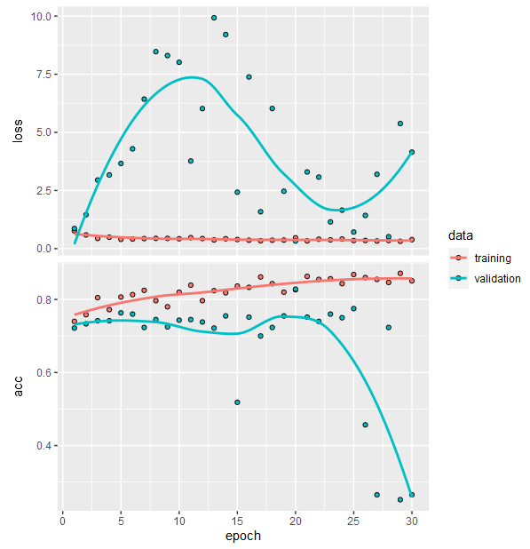

Na danych testowych dopasowanie tego modelu osiąga 30%.

## Podsumowanie

Celem tego projektu było zbudowanie optymalnego modelu klasyfikującego zdjęcia RTG klatek piersiowych ludzi, czy są oni chorzy na zapalenie płuc, czy nie. Zatem było to zadanie klasyfikacji dwustanowej.

Badanie rozpoczęto od budowy modelu bazowego, w którym występowało przeuczenie, aby dowiedzieć się, jak duży model będzie potrzebny, aby był on optymalny do tego zadania. Następnie zbudowano kilka modeli, które miały mniej złożone architektury i okazywały się lepsze od pierwotnego modelu, ponieważ w procesie ich uczenia nie występowało zjawisko nadmiernego dopasowania, ani niewystarczającego dopasowania, a poziom dopasowania do danych testowych był bardzo dobry. Zastosowano także wstępnie wytrenowany model VGG16 na zbiorze *ImageNet*, w którego wynikach nie występowało przeuczenie, ani niedouczenie, jednak dopasowanie ze względu na metrykę *accuracy* w porównaniu do innych zaprezentowanych tu modeli nie było tak dobre. Przeprowadzono także augmentację obrazów, na którą składało się kilka przekształceń. Model uczący się na tych obrazach nie poprawił jednak nadmiernego dopasowania pierwotnego modelu.

W tym zadaniu doszliśmy do kilku modeli dardzo dobrze dopasowanych do danych. Były one stosunkowo mało rozbudowane. Składały się z czterech, bądź pięciu stosów naprzemiennych warstw `layer_conv_2d` oraz `layer_max_pooling_2d`, po których następowała warstwa `layer_flatten` oraz warstwa `layer_dense` o rozmiarze 512 z aktywacją `relu` oraz druga taka warstwa o rozmiarze 1 i aktywacją `sigmoid`.

Modelem wykazującym się najlepszym dopasowaniem (95%) do nowych danych oraz nie wykazującym się ani przeuczeniem, ani niedouczeniem, okazał się model o następującej architekturze:

```
Model: "sequential_4"
________________________________________________________________________________
Layer (type)                        Output Shape                    Param #
================================================================================
conv2d_21 (Conv2D)                  (None, 148, 148, 16)            448
________________________________________________________________________________
max_pooling2d_21 (MaxPooling2D)     (None, 74, 74, 16)              0
________________________________________________________________________________
conv2d_20 (Conv2D)                  (None, 72, 72, 64)              9280
________________________________________________________________________________
max_pooling2d_20 (MaxPooling2D)     (None, 36, 36, 64)              0
________________________________________________________________________________
conv2d_19 (Conv2D)                  (None, 34, 34, 128)             73856
________________________________________________________________________________
max_pooling2d_19 (MaxPooling2D)     (None, 17, 17, 128)             0
________________________________________________________________________________
conv2d_18 (Conv2D)                  (None, 15, 15, 256)             295168
________________________________________________________________________________
max_pooling2d_18 (MaxPooling2D)     (None, 7, 7, 256)               0
________________________________________________________________________________
flatten_4 (Flatten)                 (None, 12544)                   0
________________________________________________________________________________
dense_9 (Dense)                     (None, 512)                     6423040
________________________________________________________________________________
dense_8 (Dense)                     (None, 1)                       513
================================================================================
Total params: 6,802,305
Trainable params: 6,802,305
Non-trainable params: 0
________________________________________________________________________________
```

Na koniec została przedstawiona predykcja tego modelu dla kilku przykładowych obrazów ze zbioru testowego.

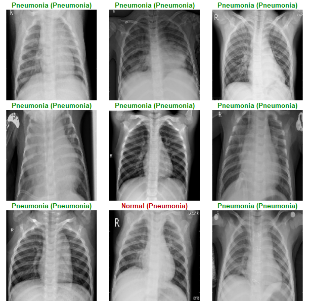